# Weight Lifting Prediction

davegoblue

April 22, 2016

## Executive Summary

Six test subjects lifted weights using five styles (A for correct, B-E for common error types) during an HAR (Human Activity Recognition) experiment. Multiple attributes (positions, accelerations, Euler angles) were sampled from wearable technology while each subject performed each exercise style multiple times (see http://groupware.les.inf.puc-rio.br/har).

Random forests using 10-fold cross-validation perform well in predicting style (A-E) with this data. A random forest using all positions, accelerations, and Euler angles achieves 99.3% accuracy in out-of-sample predictions. Varying the predictors to be very sparse (3 sensors) or to take full advantage of structure intrinsic to the experiment changes the accuracy of out-of-sample predictions by roughly +/- 0.6%.

At the conclusion, we were asked to predict the style for a set of 20 data points. The model described in the main body agrees with two alternate models (Appendix only) as to style for each of the 20 data points.

## Data Loading, Preparation, and Cleaning

### *Data Loading*

Data were downloaded as provided by the instructions in “Practical Machine Learning”, a Coursera module created by JHU. The analysis data set is “pml-training.csv” while “pml-testing.csv” contains the 20 data points that we are asked to predict for the quiz. See Appendix 4 for verbose download code (only CSV read shown here).

```
## [1] "Using existing versions of pml-training.csv and pml-testing.csv"
##                      size mode               mtime
## pml-training.csv 12222368  444 2016-04-22 12:31:47
##                  size mode               mtime
## pml-testing.csv 15134  444 2016-04-22 12:31:48
```

```r
pml_training <- read.csv("pml-training.csv", stringsAsFactors=FALSE, na.strings=c("NA",""))
pml_testing <- read.csv("pml-testing.csv", stringsAsFactors=FALSE, na.strings=c("NA",""))

dim(pml_training); dim(pml_testing)
```

```
## [1] 19622   160
```

```
## [1]  20 160
```

```r
identical(names(pml_training)[1:159], names(pml_testing)[1:159])
```

```
## [1] TRUE
```

```r
print(paste0("Divergent names in column 160 are ",names(pml_training)[160],
             " in training and ",names(pml_testing)[160]," in testing"))
```

```
## [1] "Divergent names in column 160 are classe in training and problem_id in testing"
```

The data sets each have 160 columns, and columns 1-159 have the same variable names. The final column contains the type we want to predict (“classe”) in the main data set, and is a placeholder in the 20-observation set. The predictive process will focus on pml_training.

### *Data Preparation (Test and Training Data Split)*

The caret library is loaded (along with randomForest, for use later), and the main data set is split such that 75% of observations are available for modelling with 25% held back to validate model prediction accuracy.

```r
library(caret, quietly=TRUE, warn.conflicts=FALSE)
library(randomForest, quietly=TRUE, warn.conflicts=FALSE)
set.seed(0418161225)

inTrain <- createDataPartition(y=pml_training$classe, p=0.75, list=FALSE)
dfTrain <- pml_training[inTrain, ]
dfValidate <- pml_training[-inTrain, ]

dim(dfTrain); dim(dfValidate)
```

```
## [1] 14718   160
```

```
## [1] 4904  160
```

```r
table(dfTrain$classe)
```

```
##
##    A    B    C    D    E
## 4185 2848 2567 2412 2706
```

### *Data Cleaning (Managing NA)*

The data have significant proportions of NA, though these are fortunately concentrated by column. As such, removing all columns with significant volumes of NA eliminates any need to impute missing values. A new data set noNATrain is created by excluding all columns containing any NA.

```r
naColSum <- colSums(is.na(dfTrain))
okCol <- which(naColSum==0) ## Use only the 0 NA columns
table(naColSum) ## All columns have either 0 NA or 14,409 (~97% of rows) NA
```

```
## naColSum
##     0 14409
##    60   100
```

```r
noNATrain <- dfTrain[,okCol] ; dim(noNATrain) ## 60 variables with no NA
```

```
## [1] 14718    60
```

## Analysis (Exploratory, Modeling)

### *Exploratory Data Analysis (Variable Inclusion)*

Quick inspection shows several variables are intrinsic to either this specific experiment or to the storage method for this specific data:

- X - an index that is perfectly correlated to style (data were sorted by style before X was created)
- User Name - the six test subjects for this experiment (zero predictive power to future)
- Timestamps (3) - dates and times when this experiment was run (zero predictive power to future)
- Window (2) - roughly, sampling intervals for this experiment (very risky as a predictor for future experiments)

For example (each color is a unique exercise type - see Appendix 4 for plotting code):

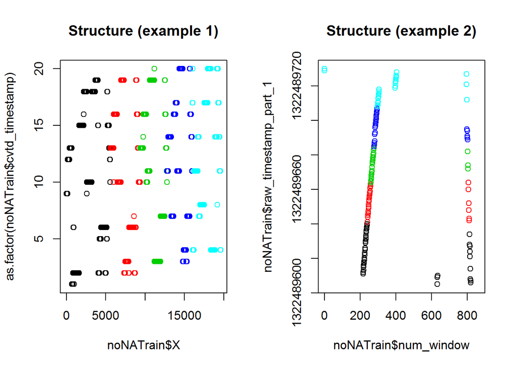

Potential predictors are split in two groups, one using only data that could likely be reproduced in other experiments (positions, accelerations, Euler angles) and another that leverages structure intrinsic to this experiment. Both predictor variable sets discard X and the character version of the timestamp. The outcomes we want to predict (“classe”) are converted to a factor and stored separately.

```r
badAll <- c("X", "cvtd_timestamp", "classe") ## Do not use outcome as predictor either
badStruct <- c("user_name", "raw_timestamp_part_1", "raw_timestamp_part_2", "new_window", "num_window")

predictorsLimit <- noNATrain[,!(names(noNATrain) %in% c(badAll, badStruct))]
predictorsFull <- noNATrain[,!(names(noNATrain) %in% c(badAll))]
outcomes <- as.factor(noNATrain$classe) ## Factor will be easier for prediction
dim(predictorsLimit) ; dim(predictorsFull) ; length(outcomes)
```

```
## [1] 14718    52
```

```
## [1] 14718    57
```

```
## [1] 14718
```

### *Exploratory Data Analysis (Model Type)*

Exploratory plotting shows promise, as certain combinations of variables tend to be highly associated with the presence and/or absence of certain exercise types. For example (see Appendix 4 for code):

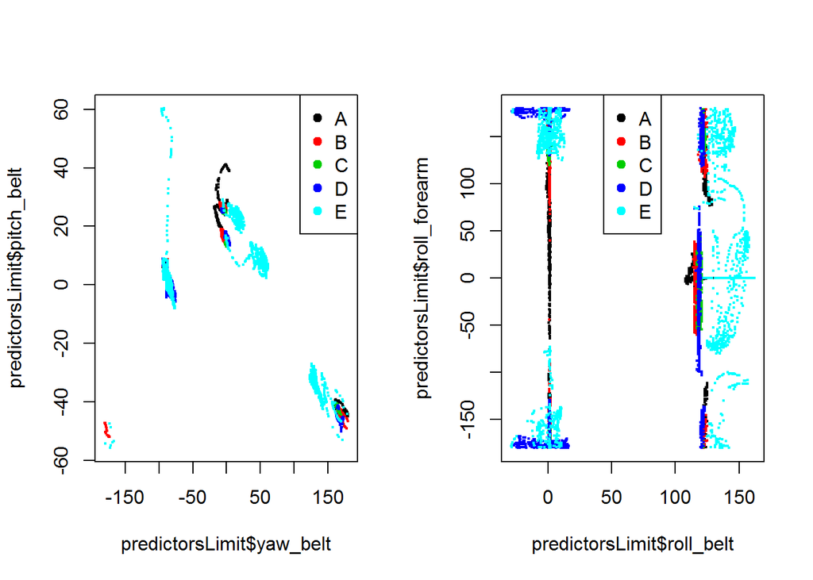

While the relationships appear reasonably strong, they are decidedly non-linear. As such, random forest will be pursued as the primary predictive technique. This obviates the need for outlier removal, as random forest is largely insensitive to monotonic transforms of the inputs.

### *Random Forest Modeling*

Random forests are generated using the narrower predictor set without structural information intrinsic to this experiment. In the interest of balancing accuracy and speed, parameters are set for 10-fold cross-validation rather than the more computationally expensive 25-resample bootstrap default. Further, the excellent multiple workers idea for parallel processing is adapted from https://github.com/lgreski/datasciencectacontent/blob/master/markdown/pml-randomForestPerformance.md

```r
## Set up the multiple workers
library(parallel, quietly=TRUE, warn.conflicts=FALSE)
library(doParallel, quietly=TRUE, warn.conflicts=FALSE)
cluster <- makeCluster(detectCores() - 1)
registerDoParallel(cluster)

## Configure train control for 10-fold cross-validation with parallel processing
parControl <- trainControl(method="cv", number=10, allowParallel = TRUE)

## Run the random forest models
rfLimit <- train(predictorsLimit, outcomes, method="rf", trControl=parControl)

## Release the workers and allow the computer to revert to sequential
stopCluster(cluster)
registerDoSEQ()
```

Summary statistics were generated, and the predictions were tested on the validation data. See Appendix 3 for the more verbose outputs of the random forest and predictions on the validation data:

```r
## Predicted out-of-sample accuracy based on 10-fold cross-validation
round(rfLimit$results[rfLimit$results$mtry==rfLimit$bestTune[[1]],],3)
```

```
##   mtry Accuracy Kappa AccuracySD KappaSD
## 1    2    0.993 0.991      0.002   0.002
```

```r
## Out-of-sample accuracy based on applying model against the validation (holdout) data
predLimit <- predict(rfLimit, dfValidate[,okCol])
round(caret::confusionMatrix(predLimit, dfValidate$classe)$overall[c(1,3:5)],3)
```

```
##      Accuracy AccuracyLower AccuracyUpper  AccuracyNull
##         0.993         0.990         0.995         0.284
```

While various model improvements could be considered (e.g., a search grid that looks closer to mtry=7 may increase accuracy by a few tenths of a percent), the main objective was to hit 99%+ accuracy in pursuit of answering 19+ of 20 quiz predictions correctly. As such, this model is used to answer the prediction quiz questions, without need for further computational expense:

```r
quizPredsLimit <- predict(rfLimit, pml_testing[,okCol])
quizPredsLimit
```

```
##  [1] B A B A A E D B A A B C B A E E A B B B
## Levels: A B C D E
```

```r
round(pbinom(15:19,20,.993,lower.tail=FALSE),3)
```

```
## [1] 1.000 1.000 1.000 0.991 0.869
```

If 20 quiz questions are iid from the same population as the modeling data, the binomial distribution predicts an 87% chance of scoring 20/20, a 99% chance of scoring 19+/20, and a 100% chance of passing with 16+/20.

## Conclusion

Random forests achieve >99% accuracy when using posititions, accelerations, and Euler angles from wearable technology to predict the type of weight lifting using the data set provided for this exercise.

Notably, all predictions are made where we know the sample is representative of the population (same test subjects, trainers, experimenters, etc.). If this experiment is replicated, it is likely that the model will require additional calibration to maintain predictive power. While we excluded a few variables that are highly instrinsic to the structure of this specific experiment, there is likely still some structure to positions, accelerations, and Euler angles based on how these individual test subjects, trainers, and experimenters performed on this specific day.

Caveats aside, the random forest does an impressive job integrating multiple pieces of information (each with somewhat limited predictive power on its own) to make highly accurate predictions within this population.

## Appendix

### *Appendix 1: Random Forest with only 9 variables*

For future replication, it may be helpful to have a model with a smaller number of variables that retains most of the accuracy. This might allow researchers to get an early read on how similar a new population is to the existing population prior to running a full experiment.

The variable importance of the final model was analyzed (see Appendix 3), and all components of three especially interesting variables (Euler belt, Euler forearm, dumbbell magnet position) were extracted and then run through a random forest. The train controls (10-fold cross-validation with parallel processing) were maintained from the full model.

```r
smallVars <- c("roll_belt", "pitch_belt", "yaw_belt",
               "roll_forearm", "pitch_forearm", "yaw_forearm",
               "magnet_dumbbell_x", "magnet_dumbbell_y", "magnet_dumbbell_z"
               )

## Set up multiple workers
library(parallel); library(doParallel)
cluster <- makeCluster(detectCores() - 1)
registerDoParallel(cluster)

## Train random forest using same parameters as previous, including only these 9 variables
rfSmall <- train(predictorsLimit[,smallVars], outcomes, method="rf", trControl=parControl)

## Release the workers and resume sequential processing
stopCluster(cluster)
registerDoSEQ()
```

This set of 9 variables achieves predicted accuracy of 98.6% (standard deviation 0.3%) in the cross-validation and actual accuracy of 98.7% (95% CI 98.4%-99.0%) when applied to the validation (holdout) dataset. It appears a reasonable trade-off of much improved interpretability and replicability in exchange for a modest loss of predictive power. Further, it makes the same predictions as to the 20-question quiz.

```r
## Descriptive statistics about smaller model
round(rfSmall$results[rfSmall$result$mtry==rfSmall$bestTune[[1]],],3)
```

```
##   mtry Accuracy Kappa AccuracySD KappaSD
## 2    5    0.986 0.982      0.003   0.003
```

```r
predSmall <- predict(rfSmall, dfValidate[,smallVars])
round(caret::confusionMatrix(predSmall, dfValidate$classe)$overall[c(1,3:5)],3)
```

```
##      Accuracy AccuracyLower AccuracyUpper  AccuracyNull
##         0.987         0.984         0.990         0.284
```

```r
## Quiz question predictions (comparison with main answer)
quizPredsSmall <- predict(rfSmall, pml_testing[,smallVars])
identical(quizPredsLimit, quizPredsSmall)
```

```
## [1] TRUE
```

### *Appendix 2: Random Forest using structure intrinsic to this experiment*

Additionally, a model is run that takes full advantage of structure intrinsic to this experiment, specifically that runs of exercise styles were done sequentially by each participant (and are thus correlated with time). While this may be of very limited if any use for making predictions anywhere other than within this dataset, it is included in the spirit of maximizing predictive power. Note that “X” is still excluded, as it appears to be a spurious variable added after sorting by exercise type.

```r
## Set up multiple workers
library(parallel); library(doParallel)
cluster <- makeCluster(detectCores() - 1)
registerDoParallel(cluster)

## Convert characters to factors
predictorsFull$user_name <- as.factor(predictorsFull$user_name)
predictorsFull$new_window <- as.factor(predictorsFull$new_window)

## Train random forest using same parameters as previous, including fullest set of variables
rfFull <- train(predictorsFull, outcomes, method="rf", trControl=parControl)

## Release the workers and resume sequential processing
stopCluster(cluster)
registerDoSEQ()
```

This master set of variables achieves predicted accuracy of 99.9% (standard deviation <0.1%) in the 10-fold cross-validation and actual accuracy of 99.9% (95% CI 99.8%-100.0%) when applied to the validation (holdout) dataset. While this slight increase in predictive power may be useful for this specific instance, the loss of replicability precludes selecting it as the final model. Notably, it makes the same predictions as to the 20-question quiz, so failing to peek at structural artifacts does not impact the quiz score.

```r
## Update the validate data to also have factors for user_name and new_window
factorValidate <- dfValidate[,okCol]
factorValidate$user_name <- as.factor(factorValidate$user_name)
factorValidate$new_window <- as.factor(factorValidate$new_window)

## Descriptive statistics about fuller model
round(rfFull$results[rfFull$results$mtry==rfFull$bestTune[[1]],],3)
```

```
##   mtry Accuracy Kappa AccuracySD KappaSD
## 2   29    0.999 0.999      0.001   0.001
```

```r
predFull <- predict(rfFull, factorValidate)
round(caret::confusionMatrix(predFull, dfValidate$classe)$overall[c(1,3:5)],3)
```

```
##      Accuracy AccuracyLower AccuracyUpper  AccuracyNull
##         0.999         0.998         1.000         0.284
```

```r
## Quiz question predictions (comparison with main answer)
## Update the quiz data to also have factors for user_name and new_window
factorQuiz <- pml_testing[,okCol]
factorQuiz$user_name <- factor(factorQuiz$user_name, levels=levels(predictorsFull$user_name))
factorQuiz$new_window <- factor(factorQuiz$new_window, levels=levels(predictorsFull$new_window))

quizPredsFull <- predict(rfFull, factorQuiz)
identical(quizPredsLimit, quizPredsFull)
```

```
## [1] TRUE
```

### *Appendix 3: Verbose Outputs of Primary Predictive Model*

```r
## More verbose outputs of model used in analysis
rfLimit
```

```
## Random Forest
##
## 14718 samples
##    52 predictor
##     5 classes: 'A', 'B', 'C', 'D', 'E'
##
## No pre-processing
## Resampling: Cross-Validated (10 fold)
## Summary of sample sizes: 13245, 13247, 13246, 13247, 13245, 13246, ...
## Resampling results across tuning parameters:
##
##   mtry  Accuracy   Kappa      Accuracy SD  Kappa SD
##    2    0.9927982  0.9908895  0.001669592  0.002112289
##   27    0.9918474  0.9896873  0.002414293  0.003052720
##   52    0.9851208  0.9811757  0.003583990  0.004535465
##
## Accuracy was used to select the optimal model using  the largest value.
## The final value used for the model was mtry = 2.
```

```r
caret::confusionMatrix(predLimit, dfValidate$classe)
```

```
## Confusion Matrix and Statistics
##
##           Reference
## Prediction    A    B    C    D    E
##          A 1394    5    0    0    0
##          B    1  941   11    0    0
##          C    0    3  843   12    0
##          D    0    0    1  791    0
##          E    0    0    0    1  901
##
## Overall Statistics
##
##                Accuracy : 0.9931
##                  95% CI : (0.9903, 0.9952)
##     No Information Rate : 0.2845
##     P-Value [Acc > NIR] : < 2.2e-16
##
##                   Kappa : 0.9912
##  Mcnemar's Test P-Value : NA
##
## Statistics by Class:
##
##                      Class: A Class: B Class: C Class: D Class: E
## Sensitivity            0.9993   0.9916   0.9860   0.9838   1.0000
## Specificity            0.9986   0.9970   0.9963   0.9998   0.9998
## Pos Pred Value         0.9964   0.9874   0.9825   0.9987   0.9989
## Neg Pred Value         0.9997   0.9980   0.9970   0.9968   1.0000
## Prevalence             0.2845   0.1935   0.1743   0.1639   0.1837
## Detection Rate         0.2843   0.1919   0.1719   0.1613   0.1837
## Detection Prevalence   0.2853   0.1943   0.1750   0.1615   0.1839
## Balanced Accuracy      0.9989   0.9943   0.9911   0.9918   0.9999
```

```r
caret::varImp(rfLimit)
```

```
## rf variable importance
##
##   only 20 most important variables shown (out of 52)
##
##                   Overall
## roll_belt          100.00
## yaw_belt            80.03
## magnet_dumbbell_z   72.95
## magnet_dumbbell_y   63.83
## pitch_belt          62.51
## pitch_forearm       61.21
## roll_forearm        53.20
## magnet_dumbbell_x   52.20
## accel_dumbbell_y    46.76
## magnet_belt_z       45.19
## magnet_belt_y       43.52
## accel_belt_z        41.90
## roll_dumbbell       41.37
## accel_dumbbell_z    38.15
## roll_arm            37.10
## accel_forearm_x     34.41
## gyros_belt_z        31.61
## accel_dumbbell_x    31.52
## yaw_dumbbell        29.29
## magnet_arm_x        29.18
```

### *Appendix 4: Verbose R Code in Appendix to improve readability*

#### *Download project files if needed*

```r
## Code set to echo=FALSE in main document and eval=FALSE here
if (file.exists("pml-training.csv") & file.exists("pml-testing.csv")) {
    print("Using existing versions of pml-training.csv and pml-testing.csv")
    print(file.info("pml-training.csv")[c("size","mode","mtime")])
    print(file.info("pml-testing.csv")[c("size","mode","mtime")])
} else {
    print("Downloading versions of pml-training.csv and pml-testing.csv")
    download.file("https://d396qusza40orc.cloudfront.net/predmachlearn/pml-training.csv",
                  destfile="pml-training.csv"
                  )
    download.file("https://d396qusza40orc.cloudfront.net/predmachlearn/pml-testing.csv",
                  destfile="pml-testing.csv"
                  )
}
```

#### *Plot data structure*

```r
## Code set to echo=FALSE in main document and eval=FALSE here
par(mfrow=c(1,2))
plot(noNATrain$X, as.factor(noNATrain$cvtd_timestamp), col=as.factor(noNATrain$classe),
     main="Structure (example 1)")
plot(y=noNATrain$raw_timestamp_part_1, x=noNATrain$num_window, ylim=c(1322489605, 1322489730),
     col=as.factor(noNATrain$classe), main="Structure (example 2)")
par(mfrow=c(1,1))
```

#### *Plot example predictors and outcomes*

```r
## Code set to echo=FALSE in main document and eval=FALSE here
par(mfrow=c(1,2))
plot(predictorsLimit$yaw_belt, predictorsLimit$pitch_belt, col=outcomes, cex=0.25)
legend("topright",legend=LETTERS[1:5],col=1:5,pch=19)
plot(predictorsLimit$roll_belt, predictorsLimit$roll_forearm, col=outcomes, cex=0.25)
legend("top",legend=LETTERS[1:5],col=1:5,pch=19)
par(mfrow=c(1,1))
```